# Unidad 3: Macroanálisis - Introducción a la Estilometría - Ejercitación

Romina De León

Hemos llegamos a la última unidad del **módulo de R** de esta Diplomatura, y como capítulo final, presentaremos el paquete [Stylo](https://cran.r-project.org/web/packages/stylo/stylo.pdf), utilizado para realizar **estilometría**. Esta pertenece al campo de las Humanidades Digitales, derivada de aplicar la lingüística computacional a diversas áreas de la lingüística aplicada, de la lingüística textual y de la filología. Asimismo, es parte del estudio del estilo lingüístico de textos escritos, se encarga de analizarlos cuantitativamente, considerando el léxico, las clases y asociaciones de palabras, sus frecuencias, con el objetivo de encontrar similitudes o diferencias entre los textos. Se podría señalar como idea general y simplificada, que estos pertenecen a un tipo común, de género, autor, estilo, etc., por lo cual comparten características léxicas similares que pueden observarse estadísticamente.

Durante este módulo, particularmente mediante el análisis textual, se relacionaron tres subcampos: la extracción de información de textos, *text mining*, estilometría computacional y técnicas de visualización de datos. Estos utilizan métodos similares o colaboran entre sí, pudiéndose encontrar dentro de las técnicas computacionales y estadísticas denominadas, **lectura lejana** y **macroanálisis** (Jockers, 2013). Ambos métodos extraen y analizan grandes cantidades de datos a partir de corpus de texto literario, buscando rasgos y patrones de comportamiento generales. En palabras de M. Jockers:

```
Indeed, the very object of analysis shifts from looking at the individual occurences of a feature in context to looking at the trends and patterns of that feature aggregated over an entire corpus (2013, p. 24).
```

Por lo cual, se considera que la minería de textos y la estilometría computacional utilizan técnicas de clasificación y agrupación, así como métodos de procesamiento del lenguaje natural o PLN (NLP sus siglas en inglés) e incluso en ciertas ocasiones redes neuronales. Por su parte, las técnicas de visualización nos facilitan la comprensión de problemas y analizar los resultados.

### Estilometría

Esta posee diferentes usos que van desde la determinación de autoría de una obra, la autenticidad, la clasificación de textos, la medición de frecuencias de palabras, la identificación de lenguas, entre otras. Por ejemplo, para poder conocer la autoría de un texto, se deberán generalizar características distintivas entre diferentes autores, para así poder realizar una comparación. Dentro de estas características definitorias están la forma de escribir, la riqueza léxica, la frecuencia de utilización de algunas palabras, el género literario preferido, las formas de utilizar signos de puntuación, etc. La estilometría tiene aplicación frecuente en formato legal, tanto académica y literaria, como en la investigación de ciertas obras de Shakespeare a la lingüística forense. Las técnicas de análisis pueden categorizarse en supervisadas y no supervisadas; las primeras son aquellas que requieren la clasificación y características de los autores; mientras que las no supervisadas hacen la categorización sin conocimiento previo del autor. Al abordar, como mencionamos, la determinación de autoría se podrían emplear redes de palabras, descomponiendo un texto en estas, almacenándolas como vértices de grafos dirigidos, donde las palabras co-ocurrentes se enlazaran unas con otras; luego se debe clasificar los textos sin autor, analizando similitudes. Actualmente se apoya en el análisis estadístico, la inteligencia artificial, así como en el enorme acceso a corpus de textos disponibles en internet[^1].

### Lectura distante / Lectura cercana (distant reading /close reading)

A través del paso del tiempo se fueron construyendo y evolucionando las prácticas de lectura incluso adaptándose a los dispositivos. El crecimiento exponencial de la cantidad de información y la variación de los soportes de lectura, como dispositivos de producción, almacenamiento y circulación textual provocaron diferentes maneras de leer totalmente disímil al de la imprenta. Por lo cual, se han establecido dos modos de realizar estas nuevas lecturas, la **distante** y la **cercana.**

Hemos mencionado que la estilometría se considera como el análisis computacional de textos literario, y por ello, se enmarca en el marco teórico y metodológico de las Humanidades Digitales, particularmente dentro de los estudios de teoría y crítica literaria de Franco Moretti[^2], con las nociones de **lectura distante** y **lectura cercana**:

> ```
> Distant reading: where distance, let me repeat it, is a condition of knowledge: it allows you to focus on units that are much smaller or much larger than the text: devices, themes, tropes–or genres and systems (2000, pp. 57-58).
> ```

Mientras que como *close reading* se puede entender la lectura atenta como actividad enfocada en un texto y dentro de él, considerando la individualidad de las palabras, las formas del pensamiento, los recursos retóricos, los patrones de descripción y caracterización, etc., es decir, acercándose al logro artístico del texto.

Por lo tanto, podemos considerar que la lectura distante o distant reading, es una de las técnicas de análisis que se encuentra vinculada a la visualización de datos, por medio de la representación gráfica, mediante la creación de modelos y la determinación de patrones de análisis; como si se pasara de un plano particular a uno general, alejando el foco del objeto de estudio.

De esta manera, para seguir adelante con la estilometría haremos uso de un marco mixto de estas teorías, considerando los distintos enfoques, la relevancia de la lectura distante a las unidades infinitamente grande, y la lectura cercana para los pequeños componentes formales que componen el texto. Podremos acceder a los grandes datos que no son accesibles con lo micro, las características lingüísticas de micronivel, pero que se asignan sobre los fenómenos de nivel macro. Finalmente, metodológicamente con la lectura distante, se podrá extraer patrones recurrentes comunes.

## Paquete Stylo

El *análisis estilístico computacional* o *análisis computacional de estilo*, tuvo sus inicios a finales del siglo XIX cuando Morgan, Mendenhall y Lutoslawski realizaron estudios pioneros[^3], donde se introdujo el término, aunque la disciplina no se constituyó como tal hasta la aparición de herramientas informáticas que podían realizar los procesamiento de datos masivos.

Como hemos mencionado, la estilometría tiene alcances muy amplio; siendo una técnica que establece patrones de similitudes y diferencias recurrentes, no perceptibles mediante la *lectura cercana*. Al basarse en la noción de *huella lingüística* o conjunto de rasgos lingüísticos, característicos del estilo de escritura de un autor o de una obra, por lo cual, con esta metodología se puede identificar el estilo individual y único que lo hace diferente a otros autores u obras.

Las marcas identitarias o características léxicas de estilo, se encuentran divididas en: riqueza del vocabulario y frecuencia de las palabras funcionales o gramaticales, *function words*. Estas últimas poseen mayor peso dentro de lo distintivo, aún más que las palabras con significado léxico, ya que no dependen del entorno (tema, género, época) y, particularmente, por que son utilizadas involuntaria e inconscientemente, configurando la marca lingüística de un autor, sin filtros racionales, es decir, la clave estilística idiosincrásica. Asimismo, junto a las **palabras más frecuentes** o **MFW**, por sus siglas en inglés (Most Frequent-Word), también se pueden añadir signos de puntuación, longitud de palabras, longitud de oraciones, patrones rítmicos, número de sílabas por palabra, distribución de *n-grams*, riqueza léxica, colocaciones o distribución de las partes de la oración.

Recordamos que, para el cálculo automático en los textos se utilizan **n–grams**, explicados en la [unidad anterior](http://hdlab.space/Estilometria-con-R/unidad2-etiquetado-pos.html), que permiten obtener una secuencia de ítemes cualquiera dentro de una frase o palabra; y tienen la ventaja que muchas de ellas pueden ser extraídas de igual forma para distintos idiomas, con un nivel de análisis relativamente sencillo utilizando herramientas existentes, como la [tokenización](http://hdlab.space/Estilometria-con-R/unidad2_analisis-textual.html).

Todas estas cuestiones fueron tenidas en cuenta, para desarrollar el paquete de R, `Stylo`, por Maciej Eder, Jan Rybicki, Mike Kestemont, Steffen Pielstroem[^4]. Esta gran librería se enfoca en el análisis de estilo literario, presenta una interfaz gráfica propia e integra las metodologías estilométricas con procedimientos estadísticos. Si bien, como se ha señalado, posee diversas funciones, lo principal es la sencillez que posee para la generación de representaciones gráficas considerando la distancia entre textos que permite evaluar y representar similitudes o diferencias estilísticas; con la visualización en dendrogramas, los archivos de un corpus aparecen agrupados según su grado de cercanía estilística; con los árboles de consenso, se realizaran un agrupamiento más robusto por estilo, pudiendo considerar diversos autores; en cambio, con los métodos de oposición entre textos, permitiría clasificar por distintos períodos o géneros; y se podría continuar enumerando funciones.

### Análisis de grupos / *cluster analysis*

Los dendrograma, diagramas arbóreos, son resultados de análisis de grupos o *cluster analysis*, técnica estadística que agrupa conjuntos de elementos, observaciones, en dos o más grupos, la semejanza se refleja cuando se encuentran en el mismo grupo (*cluster*). Este tipo de análisis, maximiza las similitudes como las diferencias entre grupos. Varios algoritmos realizan esta metodología, como el análisis jerárquico, que inicia considerando cada caso como un grupo, posteriormente los combina secuencialmente, y va redujendo así, los grupos en cada paso hasta que al final solo queda uno. Para su cálculo se utilizan métodos estadísticos, que consideran datos de frecuencia, n-grams, cálculo de la distancia. La distancia entre frecuencias, sufrieron diversas actualizaciones considerando inicialmente la Euclidiana, que toma el camino más corto entre dos elemento, sin embargo, actualmente la más utilizada en la Delta de Eder. Esta última es una de las más usadas en los problemas de autoría, fue propuesta por John Burrows en 2002 y actualizada por Maciej Eder para el paquete Stylo[^5].

A continuación se presenta como resultaría el análisis si utilizásemos discursos y DNU (Decreto de Necesidad y Urgencia) de la [ejercitación de análisis textual](http://hdlab.space/Estilometria-con-R/unidad2_ej_analisis_textual.html), seteando las MFW entre 200 y 1000, con la variante de distancia Eder Delta.

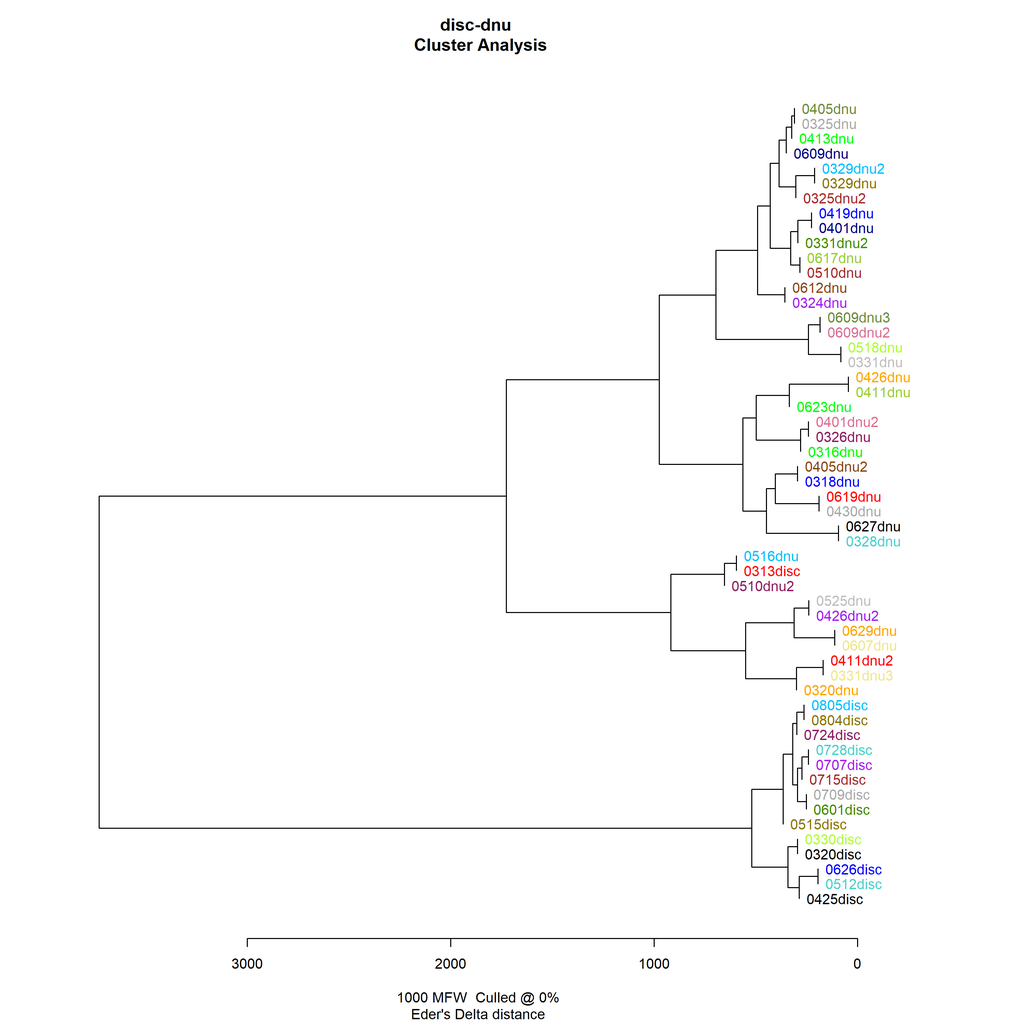

De esta manera, se puede visualizar una de las funciones de `Stylo`, donde separa distintitos tipos de escritura y tiene en cuenta las palabras funcionales. Ahora pensemos que sucedería si utilizamos, por ejemplo sólo discursos, podremos saber si existen distintos tipos de escritura, es decir, ¿si siempre son escritos por la misma persona?

Eder’s Delta

Classic Delta

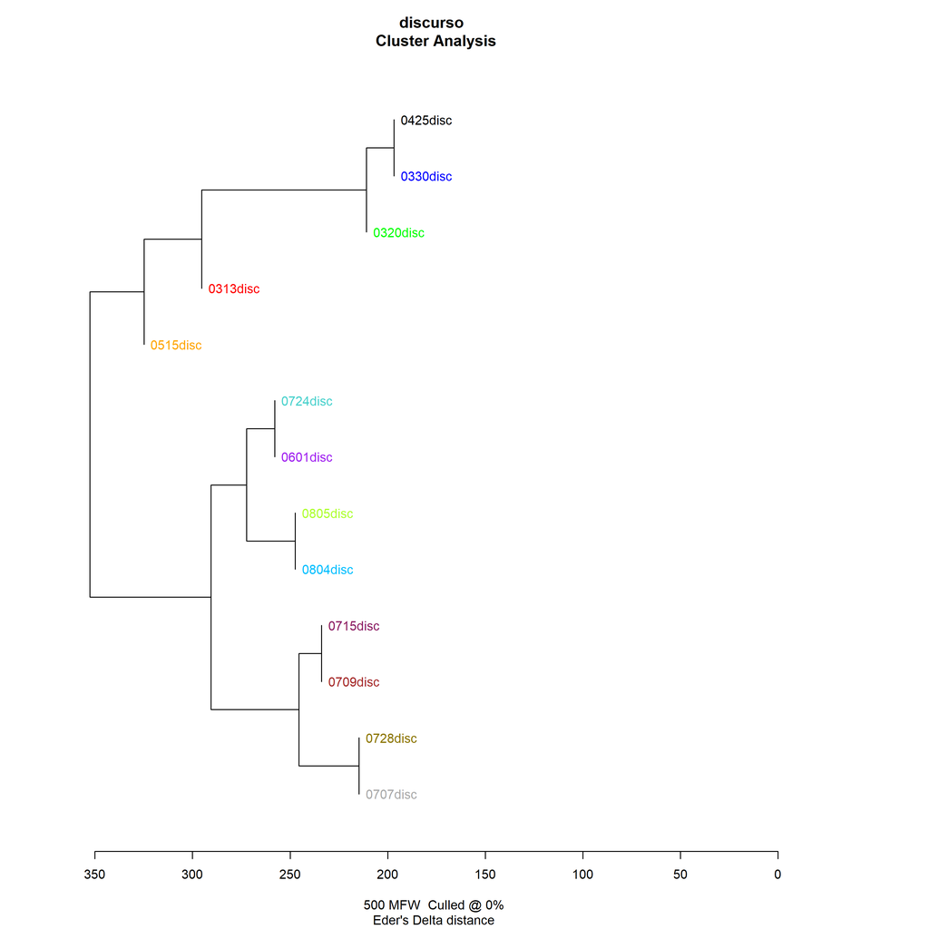

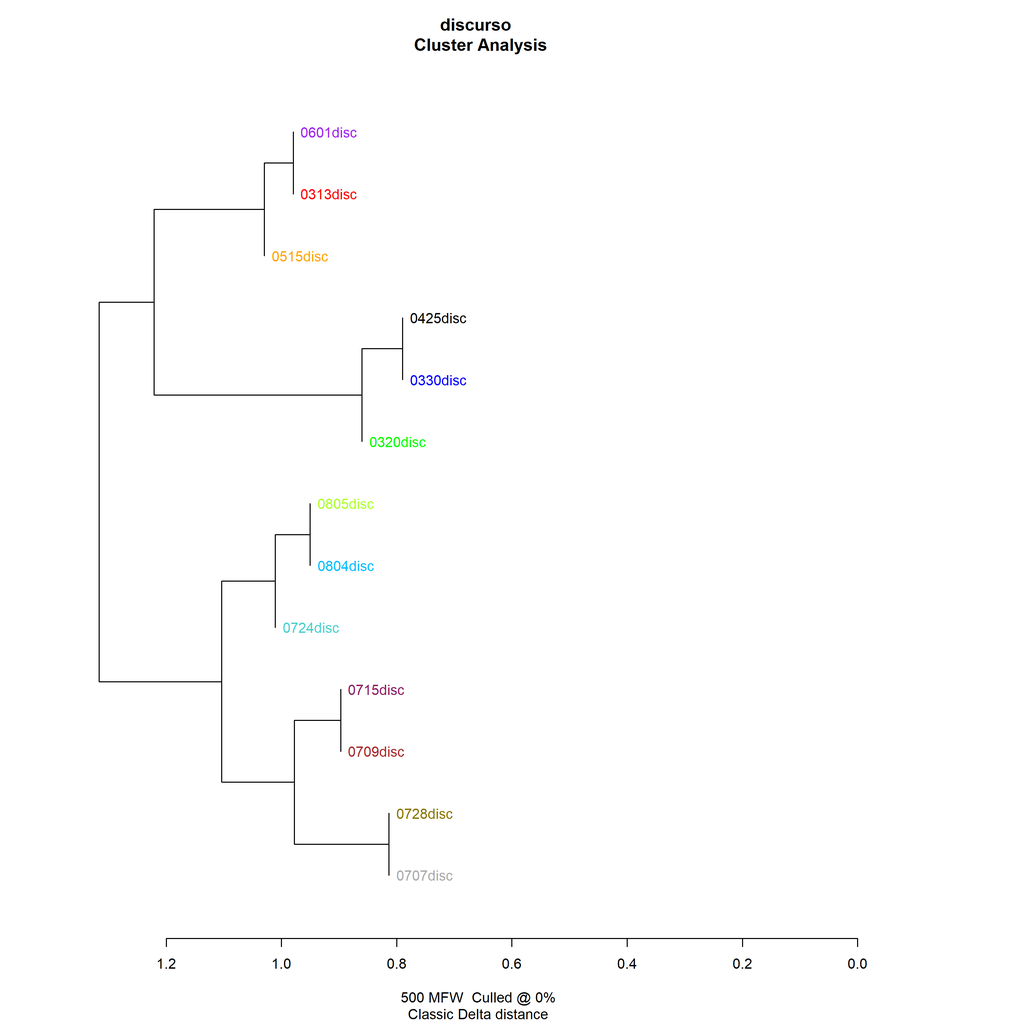

En ambos gráficos, hemos utilizados MFW entre 100 y 500, con 1 n-grams, variando el cálculo de distancia, utilizando el Delta clásico y el de Eder, recuerden que estos dos modelos son los más afines para estilometría, particularmente para comparar autoría. En ambos gráficos, se pueden observar dos grandes ramificaciones, que se abren en dos, y sabemos que los que están más cerca es porque comparten estilo y palabras más utilizadas, por ende podrían estar escritos por al menos dos personas. Podíamos realizar diversos análisis, por ejemplo sustituyendo el procesamiento de palabras por *n-grams*, pues en español se producen agrupaciones de tres o más “tokens”, debido a la configuración de frases, colocaciones, perífrasis verbales, etc.; o modificando la cantidad de MFW. Estas consideraciones no forman parte de este curso, pero si es fundamental comprender que según la separación de las ramas y de cuáles se encuentran en la misma ramificación, más cerca o más lejos indicará similitudes o diferencias.

### Árbol de consenso / Consensus Tree

Otro tipo de gráfico que nos permite realizar `Stylo` son los árboles de consenso, *Bootstrap Consensus Tree (BCT),* estos se realizan a partir de los *cluster analysis*, toman gran cantidad de estos, considerando mínimo y máximo de MFW, luego se agrupan, por ello se dice que hace consenso, y se presenta el resultado con una representación arbórea. El método BCT estabiliza los resultados al dividir las MFW en bandas de frecuencias, superponiéndolas y luego analizándolas independientemente[^6]. Los siguientes dos gráficos, han tenido en cuenta, discursos y DNU en el primero; solo discursos en el segundo.

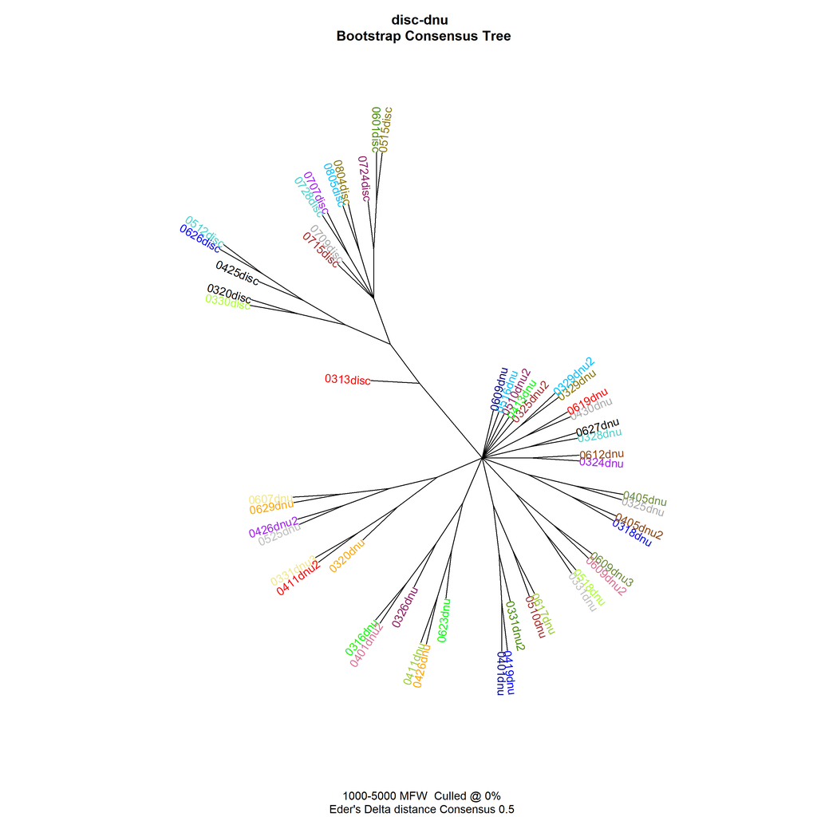

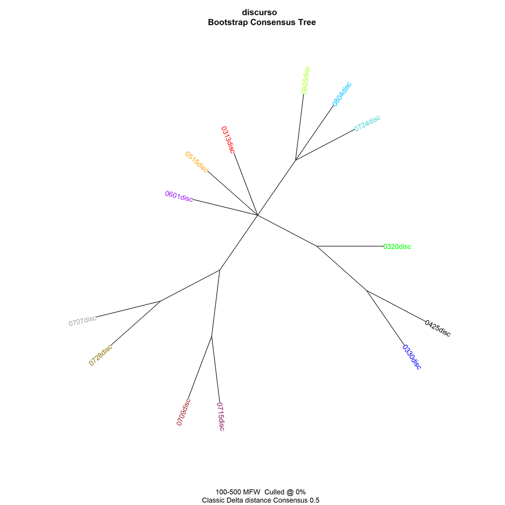

Este tipo de análisis es considerado más robusto, pues toma todos los *cluster analysis*, realizados en iteraciones, trabajando primero con el mínimo de MFW, luego realizando incrementos hasta llegar al máximo, y generando nuevos agrupamientos en cada repetición. Por ello, se puede comprender que la relación jerárquica de las diversas ramas representan la distancia entre los textos.

### Análisis de componentes principales / Principal Component Analysis (PCA)

Continuando con otro tipo de análisis de `Stylo`, llegamos a uno de los más utilizados, *Principal Component Analysis*[^7], pertenece a la familia de técnicas *unsupervised learning*. Se puede explicar, de manera reducida y simplista, que este análisis entiende a cada palabra como una dimensión diferente; cada texto recibe un valor para cada dimensión, por lo que cada texto termina definido por valores de distintas dimensiones (MFW que seleccionamos); es decir, que simplifica la complejidad de espacios con muchas dimensiones pero conserva su información; y extrae la información empleando predictores, para, por ejemplo, poder identificar subgrupos. Estas visualizaciones presentan los resultados en dos componentes principales, rotados en los ejes de coordenadas cartesianas.

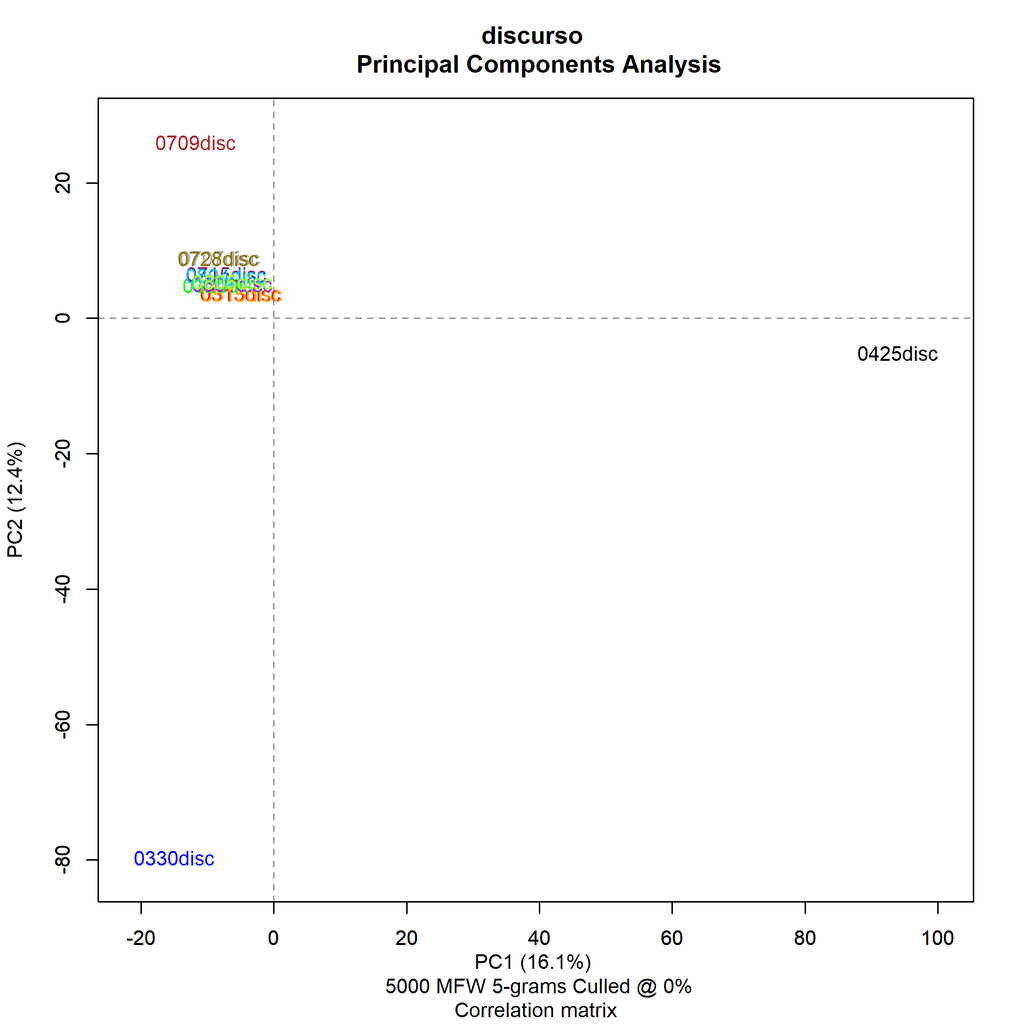

Asimismo, cabe destacar que existen dos maneras de interpretar la repetición de cadenas largas en diversos textos, una puede ser como desidia y la otra, como coherencia, pues la estilometría no podrá diferencias el fondo del texto, si se analizan ideas, pues se puede expresar una misma idea con diversas palabras, y allí la estilometría no podría reconocer la similitud.

### Otras funciones de Stylo

Otras funciones[^8] utilizadas en en esta librería son:

> classify() que permitirá realizar una validación cruzada mediante métodos de clasificación, configurando dos subdirectorios, “primary sets” y “secondary sets”.

> rolling.classify() que combina la clasificación de aprendizaje automático supervisado con la idea de análisis secuencial, intenta observar dentro de un texto representado como conjunto de fragmentos cortados linealmente, para probar su consistencia estilística. Deben configurarse dos subdirectorios: “reference_set” y “test_set”.

Hasta aquí, hemos presentado la parte teórica de esta sección de **Macroanálisis**, a continuación realizaremos la parte práctica.

## Ejercitación

Para esta ejercitación volveremos con los datos de la unidad anterior, [Ejercicio de análisis textual](http://hdlab.space/Estilometria-con-R/unidad2_ej_analisis_textual.html). Nos situaremos en la carpeta `disc-dnu` conformada por los textos ya mencionados en dicha unidad.

```r
rm(list = ls())

getwd()

setwd("C:/hdcaicyt/R/disc-dnu")
```

Como se mencionó en la teoría instalaremos el paquete **Stylo** y llamaremos a la librería:

```r
install.packages("stylo") #tardará unos cuantos minutos
```

```r
library(stylo)
```

Una particularidad de `Stylo` es que necesita colectar sus textos de un directorio denominado `corpus`, por ello dentro de nuestra carpeta `/disc-dnu` crearemos esa nueva dirección mediante la función `dir.create` poniendo entre comillas el nombre de la carpeta a crear:

```r
setwd("/~/disc-dnu/")

dir.create("corpus")

list.files("/hdcaicyt/R/disc-dnu/corpus") #modifica tu path para acceder correctamente y listar los archivos de la carpeta "corpus"
```

Ahora llamaremos al paquete `Stylo()`, y se nos abrirá una ventana como la siguiente:

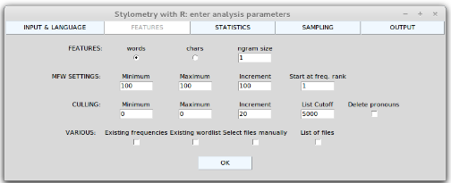

Allí primero iremos a la ventana **input & language** donde seleccionaremos el tipo de archivo, idioma y *native encoding*; luego modificaremos **features**, podemos elegir “words”, “chars” y los “n-grams” (importante considera las explicaciones en la teoría de esta ejercitación), las palabras más frecuentes (**MFW**), mínimo, máximo e incremento; etc. En **statistics** podremos elegir tipo de análisis a realizar, *cluster*, *PCA*, *consensus tree*, *culling* (porcentaje de aparición de MFW en los textos); etc. y el tipo de distancia a utilizar; en **sampling** podremos pedirle que divida el corpus en determinada cantidad de palabras, normal o aleatoria; y finalmente en **output** elegiremos formatos de visualización, tamaño, guardado de imagen, etc.

```r
stylo()
```

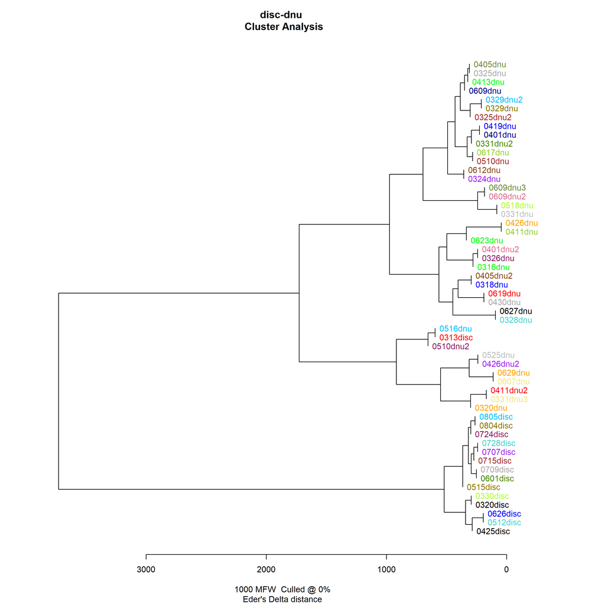

Te propongo que realices algunas variaciones en los parámetros para obtener distintas gráficas, podría ser un árbol de consenso y otra realizando un gráfico de **PCA**.

*Ahora veremos otra manera de cargar y realizar visualizaciones con Stylo, de forma manual y no automatizada como la anterior.*

Para ello primero, mediante la función `load.corpus`, de la misma librería, podremos cargar todos nuestros archivos que se encuentren en el directorio *corpus*, pero aclararemos cuáles queremos que seleccione (debes recordar que Stylo puede analizar archivos de texto plano, *.txt, XML o HTML), además deberemos indicar el tipo de codificación.

```r
corpus_all <- load.corpus(files = 'all', corpus.dir = 'corpus', encoding = 'UTF-8')

summary(corpus_all)
```

```
##
## Function call:
## load.corpus(files = "all", corpus.dir = "corpus", encoding = "UTF-8")
##
## Number of texts/samples:         54
## Total number of units:           10860
## Number of units in samples:
##
##                 0313disc.txt...  44
##                  0316dnu.txt...  35
##                  0318dnu.txt...  35
##                 0320disc.txt...  23
##                  0320dnu.txt...  138
##                  0324dnu.txt...  87
##                  0325dnu.txt...  79
##                 0325dnu2.txt...  117
##                  0326dnu.txt...  87
##                  0328dnu.txt...  61
##                             ...  ...
##
## Depending if the corpus has been tokenized or not, the "units" mean
## tokens (words, word pairs, POS-tags, character n-grams, etc.),
## or strings of text (usually paragraphs) ending with a newline char.
```

Posteriormente, le pediremos que *tokenice* el corpus a trabajar, es decir, que divida las cadenas de caracteres en palabras, removiendo signos de puntuación, etc., para ello, utilizaremos la función `txt.to.words.ext`, el primer parámetro que indicaremos es el texto a ingresar, mediante *corpus_all* pediremos que seleccione todo los archivos en *corpus*, con *corpus.lang* especificaremos el idioma de los textos, por último tendremos decidiremos si tenemos en cuenta mayúsculas o no, por medio de *preserve.case*.

```r
tokenized.corpus <- txt.to.words.ext (corpus_all, corpus.lang = "Spanish", preserve.case = FALSE) # Tokeniza los textos


corpus.no.pron <- delete.stop.words(tokenized.corpus, stop.words = stylo.pronouns(corpus.lang = "Spanish")) # Elimina las palabras vacías
```

Con este último comando, le pedimos que elimine mediante `delete.stop.words` las palabras vacías, primero indicamos que dataset debía limpiar y luego que vector de *stopwords* debía considerar. Puedes acceder al contenido escribiendo: `corpus.no.pron` o `view(corpus.no.pron)`

Ahora realizaremos el calculo de palabras más frecuentes, mediante la función `make.frequency.list`, donde indicaremos los datos a analizar, y limitaremos la cantidad mediante *head*. Con estos datos armaremos una tabla, por medio de `make.table.of.frequencies`, donde indicaremos los datos a tener en cuenta, el vector de referencia, en este caso *frequent.f*, y si debe calcular las frecuencias relativas o no, cuando este argumento está en TRUE, se calculan las frecuencias relativas en lugar de las frecuencias sin procesar. Por lo cual, pediremos que primero calcule las frecuencias absolutas y luego las relativas.

```r
frequent.f <- make.frequency.list(corpus.no.pron, head = 3000)

freqs <- make.table.of.frequencies(corpus.no.pron, features = frequent.f, relative = FALSE) #frecuencias absolutas

freqs_rel <- make.table.of.frequencies(corpus.no.pron, features = frequent.f) #frecuencias relativas
```

Ahora, reduciremos nuestros datos, mediante `perform.culling`, donde especificaremos los valores de selección y el grado en que eliminaremos palabras que no figuran en todos los textos del corpus; primero indicaremos los datos de entrada y luego el nivel de reducción, siendo el porcentaje que debe considerarse para no eliminar la palabra.

Con los siguientes comandos calcularemos la frecuencia absoluta, y con los posteriores, las relativas.

```r
culled.freqs <- perform.culling(freqs, culling.level = 50) #reducción por frecuencia absoluta
```

```r
culled.freqs_rel <- perform.culling(freqs_rel, culling.level = 80)  #reducción por frecuencia relativa
```

A continuación, llamaremos el paquete `Stylo`, pero no de forma automática, sino indicando los parámetros que nosotros queremos. Primero le indicamos la frecuencia que debe considerar, *frequencies*, y luego le indicamos que no muestre la interfaz gráfica (GUI), sino que realice los análisis por *Default* seteados. Si queremos modificar la cantidad de MFW, deberemos volver a `perform.culling` y modificar el nivel.

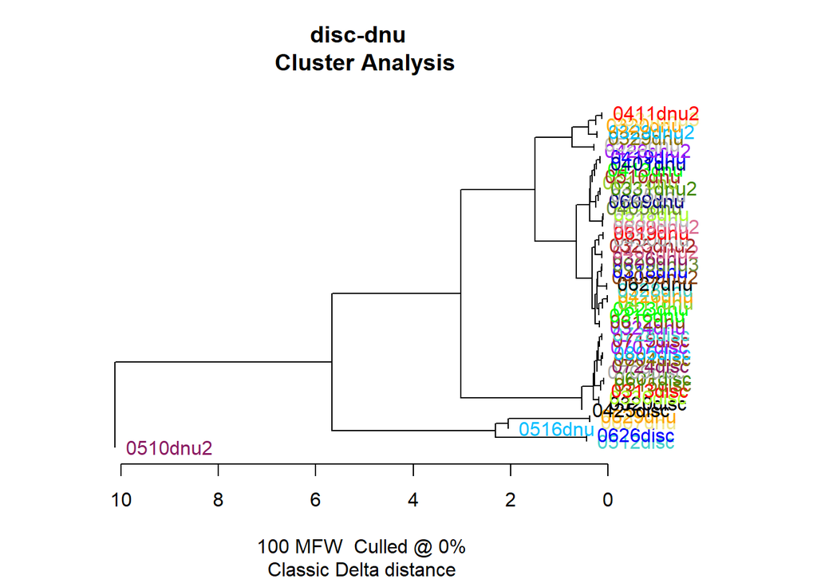

```r
stylo(frequencies = culled.freqs, gui = FALSE)
```

También podemos cambiar el tipo de análisis que deseamos mediante *analysis.type* (CA; BCT; PCR, etc), agregar título con *custom.graph.title*, indicar mínimo y máximo de MFW *mfw.min =* , *mfw.max =* , indicar si queremos guardarlo como imagen *write.png.file = TRUE*.

[output not shown]

[output not shown]

[output not shown]

[output not shown]

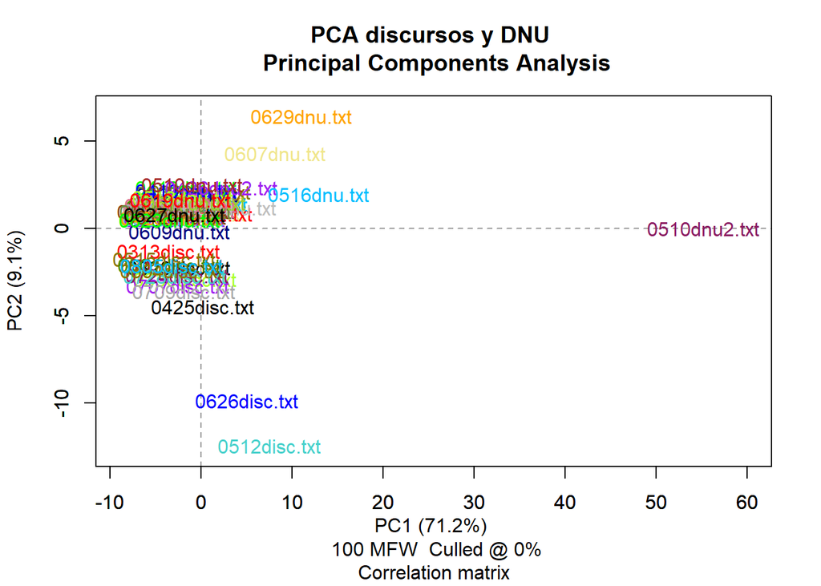

```
##
## Function call:
## stylo(gui = FALSE, frequencies = culled.freqs, analysis.type = "PCR",     custom.graph.title = "PCA discursos y DNU")
##
## Depending on your chosen options, some results should have been written
## into a few files; you should be able to find them in your current
## (working) directory. Usually, these include a list of words/features
## used to build a table of frequencies, the table itself, a file containing
## recent configuration, etc.
##
## Advanced users: you can pipe the results to a variable, e.g.:
##   my.cool.results = stylo()
## this will create a class "my.cool.results" containing some presumably
## interesting stuff. The class created, you can type, e.g.:
##   summary(my.cool.results)
## to see which variables are stored there and how to use them.
##
##
## for suggestions how to cite this software, type: citation("stylo")
```

```r
stylo(frequencies = culled.freqs, gui = FALSE, analysis.type = 'PCR', custom.graph.title = "PCA discursos y DNU")
```

### Práctica

- Realizar un análisis de comparación de textos, separando por autores y periodo (*opcional*), mediante las funciones de análisis de cluster en un corpus de [novelas hispanoamericanas](https://github.com/cligs/textbox/tree/master/spanish/novela-hispanoamericana).
  - Primero deberás descargar los archivos de la [carpeta](https://github.com/cligs/textbox/tree/master/spanish/novela-hispanoamericana/txt_id), anidando una iteración que descargue los archivos y los guarde en la carpeta `corpus`.
- Realizar nube de palabras desestimando palabras vacías.

## Bibliografía recomendada:

Jockers, M. (2013). *Macroanalysis. Digital Methods and Literary History*. Chicago: University of Illinois Press.

Moretti, F. (2005). *Graphs, maps, trees: Abstract Models for a Literary History*. Verso.

Craig, H. (2004). Stylistic Analysis and Authorship Studies. En S. Schreibman, R. Siemens y J. Unsworth, *A Companion to Digital Humanities*. Oxford: Blackwell. http://www.digitalhumanities.org/companion/.

Eder, M., Kestemont, M. y Rybicki, J. (2013). Stylometry with R: a suite of tools. *DH*. http://cls.ru.nl/~ihendrickx/Posters_ehum/4_Eder_Kestemont_Rybicki_Poster.pdf.

[^1]: Pueden verse casos de interés en: https://es.wikipedia.org/wiki/Estilometr%C3%ADa#Casos_pr%C3%A1cticos_de_inter%C3%A9s. También el artículo de Eder, M., Rybicki, J., y Kestemont, M.(2016). “Stylometry with R: a package for computational text analysis”. *R Journal* *8* (*1*): 107-121. Accesible desde: https://journal.r-project.org/archive/2016-1/eder-rybicki-kestemont.pdf.
[^2]: Moretti, F. (2000). Conjectures on world literature. *New Left Review*, *1*, 54-68. https://newleftreview.org/issues/ii1/articles/franco-moretti-conjectures-on-world-literature.pdf
[^3]: Para más información sobre la historia de la estilometría, véase: Holmes, D. I. (1998). The evolution of stylometry in humanities scholarship. *Literary and Linguistic Computing*, *13*(*3*), 111-117. https://doi.org/10.1093/llc/13.3.111 y Lutolawski, W. (1898). Principes de stylométrie. *Revue des Études Grecques*, *11* (*41*), pp. 61-81. https://www.persee.fr/doc/reg_0035-2039_1898_num_11_41_5847.
[^4]: Más información del paquete de Stylo: https://github.com/computationalstylistics/stylo.
[^5]: Para más información sobre distancia Delta:

    Argamon, S. (2008). Interpreting Burrows’s Delta: geometric and probabilistic foundations. “Literary and Linguistic Computing”, 23(2): 131-47.

    Burrows, J. (2002). ‘Delta’: A Measure of Stylistic Difference and a Guide to Likely Authorship. *Literary and Linguistic Computing,* *17*(3): pp. 267-87.

    Eder, M. (2015). Taking stylometry to the limits: benchmark study on 5,281 texts from Patrologia Latina. In: “Digital Humanities 2015: Conference Abstracts”. https://zenodo.org/record/1321296#.XzK5APgzagQ.

    Evert, S., Proisl, T., Jannidis, F., Reger, I., Pielstrom, S., Schoch, C. and Vitt, T. (2017). Understanding and explaining Delta measures for authorship attribution. *Digital Scholarship in the Humanities*, *32*(suppl. 2): 4-16.

    Calvo Tello, J. (2016, mayo 27). Entendiendo Delta desde las Humanidades. *Caracteres*. http://revistacaracteres.net/revista/vol5n1mayo2016/entendiendo-delta/
[^6]: Para más información sobre los BCT puede consultarse Eder, M., Rybicki, J. y Kestemont, M. (2016). Stylometry with R: a Package for Computational Text Analysis. *R Journal*, *8*(1): 107-121. https://journal.r-project.org/archive/2016-1/eder-rybicki-kestemont.pdf.
[^7]: Para más detalles sobre PCA, puede consultarse Jackson, J. E. (2003). *A User’s Guide to Principal Components*. Hoboken, N. J.: Wiley.
[^8]: Para más información sobre la función classify() puede consultar: https://computationalstylistics.github.io/blog/cross-validation/, y para rolling.classify() https://computationalstylistics.github.io/blog/rolling_stylometry/.